# STAT 209: Lab 9

Colin Reimer Dawson

July 8, 2021

# Reshaping data for fun, profit, and “tidyness”

## Goal

Become comfortable recognizing when reshaping data will make it better suited to the task at hand, and learn how to do so with the `pivot_longer()` and `pivot_wider()` verbs in the `tidyr` package (part of the all-powerful `tidyverse`).

**Note:** The reshaping performed by `pivot_longer()` and `pivot_wider()` was previously done by the verbs `gather()` and `spread()`, respectively. If you have the 1st edition of the textbook, you may have read about these. They still work, but have been superseded by the two `pivot_` functions, which are a bit simpler to use and also more flexible.

## The Data

Should we try to squeeze some more insight out of the `babynames` data? Let’s try to squeeze some more insight out of the `babynames` data. At least to start with.

Let’s make sure the relevant packages and datasets are loaded.

**Code:**

```r
library(tidyverse)
library(babynames)
data(babynames)    ## SSA data
data(births)       ## Census data
```

### Some preparatory wrangling (and review of joins, etc.)

In the last lab, we joined the Social Security `babynames` data with the Census `births` data to produce a table that had two records of the total number of births in each year; one from each source.

Here’s the code we used to do it (below is the “full join” version).

**Code:**

```r
census_births <- births
ssa_births <- babynames %>%
  rename(num_births = n) %>%
  group_by(year) %>%
  summarize(
    num_rows = n(),
    births   = sum(num_births))
total_births <-
  ssa_births %>%
  full_join(census_births, by = "year")
```

To make sure it worked as expected let’s take a peek at a random sample of the joined data. Remeber that since a few years are only in one dataset or the other, there will be some missing values (`NA`).

**Code:**

```r
total_births %>%
  sample_n(size = 5)
```

```
## # A tibble: 5 x 4
##    year num_rows births.x births.y
##   <dbl>    <int>    <int>    <int>
## 1  1920    10755  2262681  2950000
## 2  1915     9357  1832461  2965000
## 3  1990    24719  3950992  4158212
## 4  1890     2695   301401       NA
## 5  1970    14780  3607420  3731386
```

The `births.x` and `births.y` variables are not very descriptive; also we don’t care so much about the `num_rows` variable, so let’s do some `select`ion (to remove `num_rows`) and `rename`ing (to replace the uninformative names with informative ones).

**Code:**

```r
total_births <- total_births %>%
  select(-num_rows) %>%
  rename(
    ssa    = births.x,
    census = births.y)
```

Let’s look at a random sample from this modified data.

```r
total_births %>% sample_n(size = 5)
```

```
## # A tibble: 5 x 3
##    year     ssa  census
##   <dbl>   <int>   <int>
## 1  1958 4131657 4255000
## 2  1934 2076507 2396000
## 3  1988 3693471 3909510
## 4  1919 2110266 2740000
## 5  1979 3327416 3494398
```

## Plotting birth counts by source

If we want to visualize the number of births over time from two different sources using two overlaid lines, we have to set the `y` aesthetic separately for each line.

Also, if we want to use a different color for each source, we have to specify them manually, line by line:

**Code:**

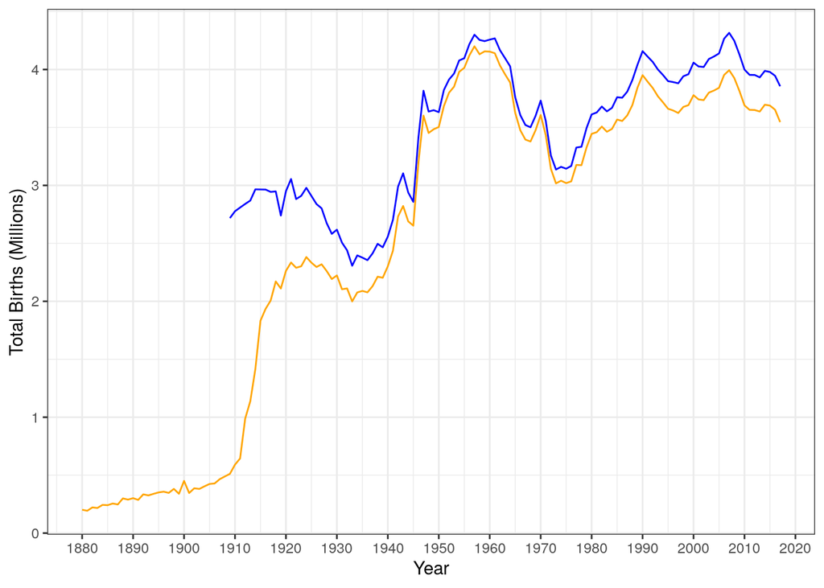

```r
total_births %>%
  ggplot(aes(x = year)) +
  geom_line(aes(y = census), color = "blue", na.rm = TRUE) +
  geom_line(aes(y = ssa), color = "orange", na.rm = TRUE) +
  scale_x_continuous(
    name   = "Year",
    breaks = seq(1880,2020,by=10)) +
  scale_y_continuous(
    name   = "Total Births (Millions)",
    breaks = seq(0,5000000,1000000),
    labels = 0:5)
```

We also don’t get a legend to tell us which source is which color. We could create this manually, but this is clunky and error-prone.

For a graph like this, we’d like to be able to create an aesthetic mapping between the `source` of the data and the `color` of the line. That mapping could then be used to automatically produce a legend. But `source` isn’t a variable in this data; it’s distinguished between variables, not between cases.

## Stacking data with the `pivot_longer()` function

Thinking about what the legend title and entries would be if we created one gives us a clue about what our dataset is missing: We need a variable called something like `source`, and a single variable to map to the $y$-axis, recording the number of births from the respective source.

We can use `pivot_longer()` for this, as follows:

**Code:**

```r
births_long <- total_births %>%
  pivot_longer(
    cols      = c("census", "ssa"), # these are the columns we're "merging"
    names_to  = "source",   # this is what we're going to call the new variable
    values_to = "births",   # this is where the stacked values will go
    )
```

```r
## The earliest years are not in the census dataset
births_long %>% slice_head(n = 5)
```

```
## # A tibble: 5 x 3
##    year source births
##   <dbl> <chr>   <int>
## 1  1880 census     NA
## 2  1880 ssa    201484
## 3  1881 census     NA
## 4  1881 ssa    192696
## 5  1882 census     NA
```

Having created the `source` variable and having merged all the counts into a single `births` variable, we can now create the line graph we want quite easily (and we get a legend automatically, since the color of the line now comes from a variable in the data table)

**Code:**

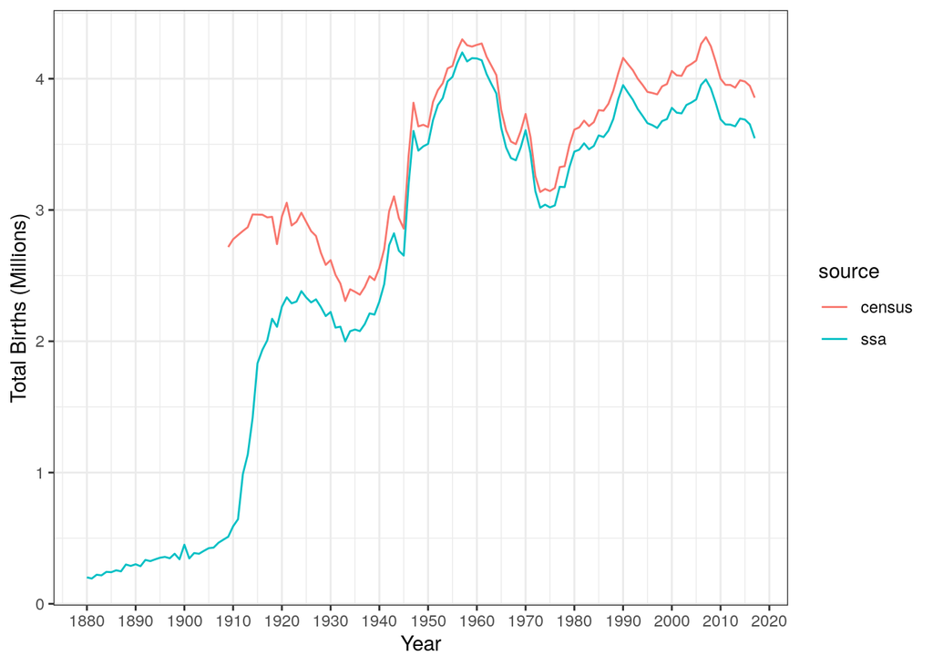

```r
births_long %>%
  ggplot(aes(x = year, y = births, color = source)) +
  geom_line(na.rm = TRUE) +
  scale_x_continuous(
    name   = "Year",
    breaks = seq(1880,2020,by=10)) +
  scale_y_continuous(
    name   = "Total Births (Millions)",
    breaks = seq(0,5000000,1000000),
    labels = 0:5)
```

## The `pivot_wider()` function

Is the “long” format we’ve created “better” in an absolute sense? Well, it’s better for producing the line graph we wanted, but suppose we wanted to visualize the correlation between the sources with a scatterplot. For a plot like this, we want one axis to be the number of births according to the SSA, and the other axis to be the number of births according to the Census. This was easy in the original data:

**Code:**

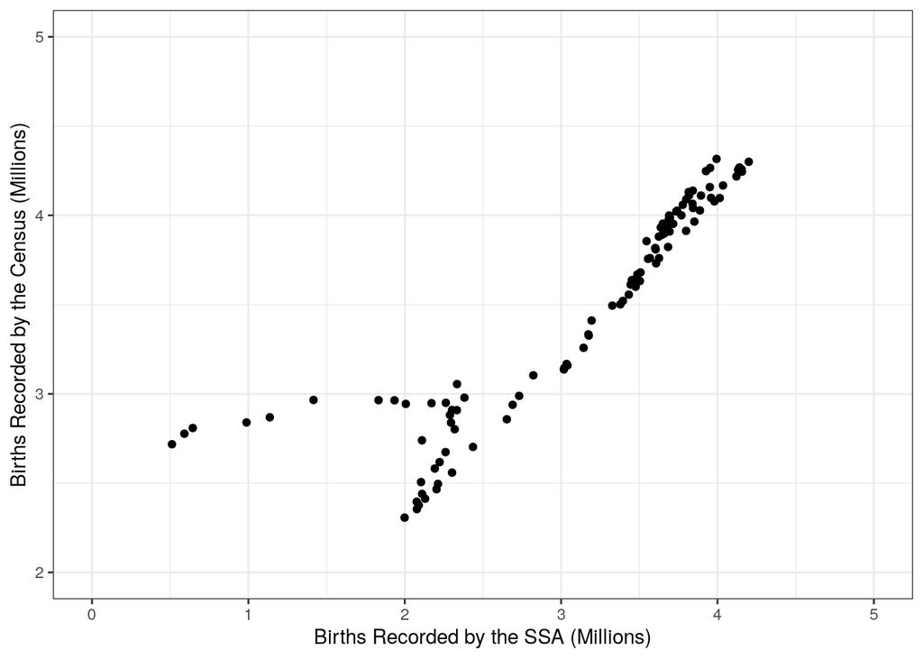

```r
total_births %>%
  ggplot(aes(x = ssa, y = census)) +
  geom_point(na.rm = TRUE) +
  scale_x_continuous(
    name   = "Births Recorded by the SSA (Millions)",
    limits = c(0,5000000),
    breaks = seq(0,5000000, by = 1000000),
    labels = 0:5) +
  scale_y_continuous(
    name   = "Births Recorded by the Census (Millions)",
    limits = c(2000000,5000000),
    breaks = seq(2000000,5000000, by = 1000000),
    labels = 2:5)
```

If the data had come to us in the “long” format, however, it would be much less obvious how to create this plot. It’s also not so clear how we’d do something like compute the correlation, or the difference between the estimates in a particular year (I suppose we could use `group_by()` and `summarize()` to do this last one, but it wouldn’t be that straightforward).

There may be times when we want to go the other direction: if we want to compute or plot something that depends on ordered pairs (or ordered tuples more generally), such as computing a correlation, or creating a new variable via `mutate()` that depends on both entries, then it is probably easier if the coordinates of those pairs (or tuples) are stored in separate variables.

The `pivot_wider()` function does this:

**Code:**

```r
births_wide <- births_long %>%
  pivot_wider(
    names_from  = source, # Unlike with pivot_longer(), this should name an existing variable
    values_from = births  # Unlike with pivot_longer(), this should name an existing variable
    )
```

### Ambiguous Matches

For `pivot_wider()` to work, it needs to know exactly what to put in each new column for each different value of the variable named in `names_from`. In order for the “wide” format to be well-defined, there must be a unique mapping from each combination of the variables we aren’t reshaping (in this case just `year`) to a *value*, for each different *key*.

If there is more than one row with the same entries in the other variables, `pivot_wider()` won’t have any way of knowing which rows to merge. It will still run, but you’ll end up with a **list** of the values from the column named in `values_from` that share the same entries elsewhere in a single entry of the widened data table.

To illustrate this, let’s create a dataset that has two instances of every row by stacking a second copy of the `births_long` below the first one.

```r
births_long_duplicated <- births_long %>% bind_rows(births_long)
```

Now let’s try to “widen” the result.

```r
births_wide_messy <- births_long_duplicated %>%
  pivot_wider(
    names_from  = "source",
    values_from = "births"
  )
```

1. View the `births_wide_messy` data in RStudio’s data viewer, and verify that each entry in the `census` and `ssa` columns is a list of two values rather than a single value. Probably not going to do anything nice for us later if we try to use this.

If, as is the case here, the problem is caused by actual duplicate entries in the data, we can just remove these duplicates before passing the data to `pivot_wider()`. There are multiple ways to do that, but an easy one is just to pass the data to the `distinct()` function, to remove completely redundant rows.

```r
births_long_deduplicated <- births_long_duplicated %>%
  distinct()
```

2. Verify that the size of the resulting `births_long_deduplicated` table is the same as the original `births_long` data.

Let’s try `pivot_wider()` again on the deduplicated data.

```r
births_wide <- births_long_deduplicated %>%
  pivot_wider(
    names_from  = source,
    values_from = births)
```

```r
births_wide %>% slice_head(n = 5)
```

```
## # A tibble: 5 x 3
##    year census    ssa
##   <dbl>  <int>  <int>
## 1  1880     NA 201484
## 2  1881     NA 192696
## 3  1882     NA 221533
## 4  1883     NA 216946
## 5  1884     NA 243462
```

Looks just like the data we started with (except for the order of the columns, and the removal of the duplicate rows)!

Now we can produce a scatterplot…

**Code:**

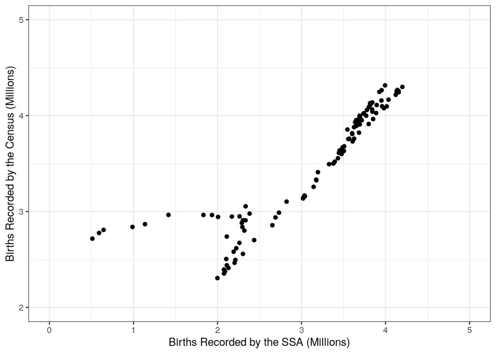

```r
births_wide %>%
  ggplot(aes(x = ssa, y = census)) +
  geom_point(na.rm = TRUE) +
  scale_x_continuous(
    name   = "Births Recorded by the SSA (Millions)",
    limits = c(0,5000000),
    breaks = seq(0,5000000, by = 1000000),
    labels = 0:5) +
  scale_y_continuous(
    name   = "Births Recorded by the Census (Millions)",
    limits = c(2000000,5000000),
    breaks = seq(2000000,5000000, by = 1000000),
    labels = 2:5)
```

(which we could do with the original data, but not with the “long” format data; here we’re just undoing what we did, but in real applications we will sometimes have data come to us in “long” format and need to convert it to “wide”)

We can also do things like compute the correlation between the sources (which also would have been difficult in the “long” form):

**Code:**

```r
## The cor() function from the mosaic package has a nicer interface than the default cor()
## function, because it has a data= argument.
## The use= argument tells cor() how to handle missing data.
mosaic::cor(census ~ ssa, data = births_wide, use = "pairwise.complete")
```

```
## [1] 0.8945154
```

or compute and plot the amount of undercounting in the SSA data relative to the Census **Code:**

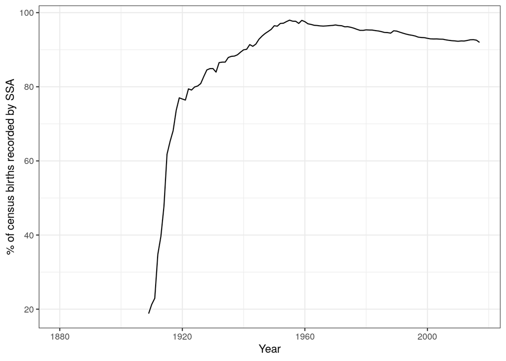

```r
births_wide %>%
  mutate(percent_in_ssa = ssa / census * 100) %>%
  ggplot(aes(x = year, y = percent_in_ssa)) +
    geom_line(na.rm = TRUE) +
    scale_x_continuous(name = "Year") +
    scale_y_continuous(name = "% of census births recorded by SSA")
```

There are some things we have tried to do before with the original `babynames` data where widening would have allowed a more concise solution.

For example, recall that the rows in the `babynames` dataset correspond to unique combinations of year, name, and sex. If we wanted to find the total number of births associated with a particular name in a particular year irrespective of sex, we have can use `group_by()` and `summarize()` to get the total by year.

3. Use `filter()`, `group_by()` and `summarize()` to find the number of births for each name in each year from 1950 to 2000. To reduce the size of the data (and the strain on the server), do the `filter()` step separately and save the resulting dataset as `babynames1950to2000`.

##### SOLUTION

```r
babynames1950to2000 <-
  babynames %>% filter(year %>% between(1950,2000))
```

```r
babynames1950to2000 %>%
  group_by(name) %>%
  summarize(
    num_births = n())
```

```
## # A tibble: 64,024 x 2
##    name     num_births
##    <chr>         <int>
##  1 Aadam            10
##  2 Aadarsh           1
##  3 Aadil             9
##  4 Aaditya           4
##  5 Aahil             1
##  6 Aailiyah          1
##  7 Aailyah           5
##  8 Aaisha           11
##  9 Aajah             1
## 10 Aakash           20
## # … with 64,014 more rows
```

This is fine, but suppose we wanted both the total *and* the number associated with the two recorded sexes in a single table. Previously this involved the somewhat awkward step of using `ifelse()` with `mutate()` to create two separate count columns, one for each value of `sex`, which contain zeroes if the row doesn’t correspond do that sex, then using `group_by()` and `summarize()` to get the totals both overall and by sex for each name in each year.

**Code:**

```r
babynames1950to2000 %>%
  rename(num_births = n) %>%
  mutate(
    num_if_amab = ifelse(sex == "M", num_births, 0),
    num_if_afab = ifelse(sex == "F", num_births, 0)) %>%
  group_by(year, name) %>%
  summarize(
    num_amab     = sum(num_if_amab),
    num_afab     = sum(num_if_afab),
    total_births = sum(num_births))
```

```
## # A tibble: 820,608 x 5
## # Groups:   year [51]
##     year name    num_amab num_afab total_births
##    <dbl> <chr>      <dbl>    <dbl>        <int>
##  1  1950 Aaron        798        7          805
##  2  1950 Abagail        0        5            5
##  3  1950 Abbe           0       10           10
##  4  1950 Abbey          0        7            7
##  5  1950 Abbie          0       68           68
##  6  1950 Abbott         9        0            9
##  7  1950 Abby           5       68           73
##  8  1950 Abdul          8        0            8
##  9  1950 Abe           46        0           46
## 10  1950 Abel         170        0          170
## # … with 820,598 more rows
```

##### SOLUTION

```r
babynames_wide <- babynames1950to2000 %>%
  pivot_wider(
  id_cols = c(year, name),
  names_from = "sex",
  values_from = "n") %>%
  rename(c("girls" = "F")) %>%
  rename(c("boys" = "M")) %>%
  mutate(
    total_births = ifelse(is.na(girls), boys,
                          ifelse(is.na(boys), girls,
                                 girls + boys))) %>% #puts total births back in the frame, not sure how to get pivot_wider() to preserve columns it's not using
  arrange(year, name)
```

By the way, using the “widened” data, we can quite easily produce a measure of how asymmetrically a name is used for male and female babies.

5. Use the wide data to find the name in each year that has the least asymmetry between male and female births, excluding names given to fewer than 100 babies overall in a given year.

```r
babynames_wide_largenums <- babynames_wide %>%
  filter(total_births > 99) %>%
  replace_na(list(girls = 0)) %>%
  replace_na(list(boys = 0)) #this took a really long time so I wanted to store it in a variable, won't call it multiple times and take more time

babynames_wide_symmetry <- babynames_wide_largenums %>%
  mutate(
    name_symmetry = abs(girls - boys)) %>%
  group_by(year) %>%
  slice_min(
    order_by = name_symmetry)

babynames_wide_symmetry
```

```
## # A tibble: 68 x 6
## # Groups:   year [51]
##     year name    girls  boys total_births name_symmetry
##    <dbl> <chr>   <dbl> <dbl>        <int>         <dbl>
##  1  1950 Kris      104   105          209             1
##  2  1951 Kris      149   145          294             4
##  3  1952 Allyn      60    50          110            10
##  4  1953 Lavern    103   103          206             0
##  5  1953 Tracy     326   326          652             0
##  6  1954 Dorian     50    56          106             6
##  7  1955 Dana     1569  1568         3137             1
##  8  1956 Lindsay    83    96          179            13
##  9  1957 Dorian     63    65          128             2
## 10  1957 Lindsay    98    96          194             2
## # … with 58 more rows
```

## Exercises

6. Find an interesting dataset from the Gapminder repository [here](http://www.gapminder.org/data/) and download the `.csv`.

```r
gapminder_adjusted_gdp <- read_csv(file = "income_per_person_gdppercapita_ppp_inflation_adjusted.csv")
```

7. Upload the `.csv` file to RStudio (assuming you are working on the server), and read it in using `read_csv()` (the function with an underscore is part of the tidyverse, and tends to work better than the built-in one with a period). You will need to supply as the argument to `read_csv()` the path to the file *relative* to the directory where your `.Rmd` is.
8. The cases in the Gapminder datasets are countries. Use `rename()` to change the first variable name to `country` (since `rename()` expects a variable name *without* quotes, you may need to surround the original variable name with backticks (the same syntax used to get a code font in Markdown) if it has spaces or special characters. Pro-tip: never use spaces or special characters (other than underscores) in variable names.

this already exists for my chosen dataset.

9. We will convert our data to a format with exactly three columns: `country`, `year`, and `value` (whatever `value` is for your chosen dataset). *Before you write any code*, sketch *on paper* what the “tidified” data will look like. Be sure to indicate how many rows it will have.

10. Use `pivot_longer()` to convert your data into this format.

```r
as.character(colnames(gapminder_adjusted_gdp))
```

```
##   [1] "country" "1799"    "1800"    "1801"    "1802"    "1803"    "1804"
##   [8] "1805"    "1806"    "1807"    "1808"    "1809"    "1810"    "1811"
##  [15] "1812"    "1813"    "1814"    "1815"    "1816"    "1817"    "1818"
##  [22] "1819"    "1820"    "1821"    "1822"    "1823"    "1824"    "1825"
##  [29] "1826"    "1827"    "1828"    "1829"    "1830"    "1831"    "1832"
##  [36] "1833"    "1834"    "1835"    "1836"    "1837"    "1838"    "1839"
##  [43] "1840"    "1841"    "1842"    "1843"    "1844"    "1845"    "1846"
##  [50] "1847"    "1848"    "1849"    "1850"    "1851"    "1852"    "1853"
##  [57] "1854"    "1855"    "1856"    "1857"    "1858"    "1859"    "1860"
##  [64] "1861"    "1862"    "1863"    "1864"    "1865"    "1866"    "1867"
##  [71] "1868"    "1869"    "1870"    "1871"    "1872"    "1873"    "1874"
##  [78] "1875"    "1876"    "1877"    "1878"    "1879"    "1880"    "1881"
##  [85] "1882"    "1883"    "1884"    "1885"    "1886"    "1887"    "1888"
##  [92] "1889"    "1890"    "1891"    "1892"    "1893"    "1894"    "1895"
##  [99] "1896"    "1897"    "1898"    "1899"    "1900"    "1901"    "1902"
```

[output cut: 20 more lines]

```r
class(colnames(gapminder_adjusted_gdp))
```

```
## [1] "character"
```

```r
gapminder_adjusted_gdp <-
  mutate_at(gapminder_adjusted_gdp,
            .vars = vars(2:242),
            .funs = function(year){ifelse(grepl("k", year),
    1000*as.double((gsub("k", "", year))), as.double(year))})
```

[output not shown]

[output cut: 412 more lines]

[output not shown]

```r
test_set <- gapminder_adjusted_gdp %>%
  summarize_all(
    .funs = function(x){sum(is.na(x))})

gapminder_longer <- gapminder_adjusted_gdp %>%
 pivot_longer(
    cols = 2:242,
    names_to = "Year",
    values_to = "Value")
```

12. The `year` variable may be stored as text instead of as a number, which will make mapping it to a positional visual cue challenging. Fix this using `mutate()`, with the help of the `parse_date()` function (supplied by the `readr` package, which is *also* part of the tidyverse). Type `?parse_date` at the console to see how to use it if it’s not clear.

```r
gapminder_longer <- gapminder_longer %>%
  mutate(
    year = parse_date(Year, "%Y"))
```

13. Plot your variable as a time series line graph, mapping `country` to `color`. Post your graph from Exercise 8 to the #lab8 channel.

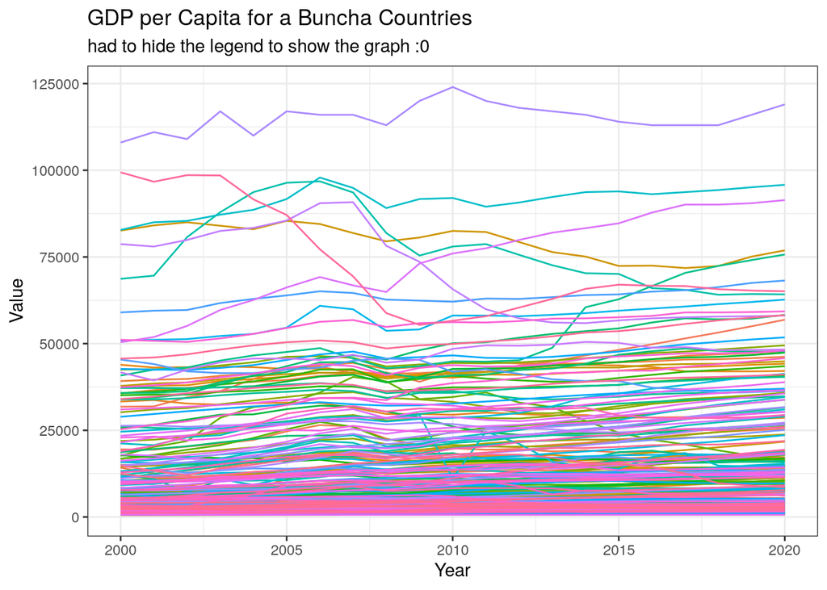

```r
gapminder_gdp_plot <- gapminder_longer %>%
  filter(Year %in% c(2000:2020)) %>%
  ggplot(aes(x = Year, y = Value)) +
  geom_line(stat = "identity", aes(x = as.numeric(Year), y = Value, colour = country)) +
  ggtitle("GDP per Capita for a Buncha Countries", subtitle = "had to hide the legend to show the graph :0") +
  theme(legend.position = "none")

gapminder_gdp_plot
```